# HW #4 — Autoencoder for MNIST Dimensionality Reduction

**Course:** Deep Learning for Computer Vision (EN525.733.8VL)  
**Due Date:** March 5, 2026

## Assignment Overview

In this assignment we build a **3-layer MLP autoencoder** to perform dimensionality reduction (compression) on the MNIST handwritten digit dataset. The autoencoder learns to compress each 784-pixel image into a smaller latent representation and then reconstruct the original image from that compressed code.

### Tasks

1. **Train autoencoders** with varying bottleneck sizes (5, 10, 20, 30, 60, 120 hidden units). Evaluate reconstruction quality using Mean Squared Error (MSE). Plot learning curves (MSE vs. epoch) for training, validation, and test sets.
2. **Visualize encoder weights** for 10 and 20 hidden units — reshape each neuron's incoming weight vector into a 28×28 image to see what visual pattern each neuron has learned.

### Approach & Hyperparameters Summary

[output not shown]

## 1. Imports and Setup

We use **PyTorch** as our deep learning framework. Key packages:

- `torch.nn` — defines the neural network layers (Linear, Sigmoid) and loss function (MSELoss)
- `torch.optim` — provides the Adam optimizer
- `torch.utils.data` — DataLoader for efficient mini-batch training
- `matplotlib` — for generating all plots
- `struct` — for reading the raw MNIST binary files

The code automatically uses GPU (CUDA) if available, otherwise falls back to CPU.

```python
import os
import struct
import numpy as np
import matplotlib.pyplot as plt
import torch
import torch.nn as nn
import torch.optim as optim
from torch.utils.data import DataLoader, TensorDataset

%matplotlib inline

device = torch.device("cuda" if torch.cuda.is_available() else "cpu")
print(f"Using device: {device}")
```

```
Using device: cuda
```

## 2. Load MNIST Data

The MNIST dataset is stored in a custom IDX binary format. Each image file has a 16-byte header containing the magic number, number of images, number of rows (28), and number of columns (28), all as big-endian 32-bit unsigned integers. The pixel data follows as unsigned bytes.

We load the raw bytes, reshape to (N, 784) (flattening each 28×28 image), and **normalize pixel values from [0, 255] to [0, 1]** by dividing by 255. This normalization is important because:

- It matches the Sigmoid output range of our decoder (which outputs values in (0, 1))
- It helps the optimizer converge faster by keeping values in a well-scaled range

```python
def load_mnist_images(filepath):
    """Read an MNIST IDX3-ubyte image file and return flattened, normalized images."""
    with open(filepath, 'rb') as f:
        magic, num_images, rows, cols = struct.unpack('>IIII', f.read(16))
        raw = np.frombuffer(f.read(), dtype=np.uint8)
    images = raw.reshape(num_images, rows * cols).astype(np.float32) / 255.0
    return images


def load_mnist_labels(filepath):
    """Read an MNIST IDX1-ubyte label file and return integer labels."""
    with open(filepath, 'rb') as f:
        magic, num_labels = struct.unpack('>II', f.read(8))
        raw = np.frombuffer(f.read(), dtype=np.uint8)
    return raw.astype(np.int64)


# Path to the MNIST data files
DATA_DIR = "archive"

train_images = load_mnist_images(os.path.join(DATA_DIR, "train-images.idx3-ubyte"))
train_labels = load_mnist_labels(os.path.join(DATA_DIR, "train-labels.idx1-ubyte"))
test_images  = load_mnist_images(os.path.join(DATA_DIR, "t10k-images.idx3-ubyte"))
test_labels  = load_mnist_labels(os.path.join(DATA_DIR, "t10k-labels.idx1-ubyte"))

print(f"Training set:  {train_images.shape[0]} images, each {train_images.shape[1]} pixels (28x28 flattened)")
print(f"Test set:      {test_images.shape[0]} images")
print(f"Pixel value range: [{train_images.min():.1f}, {train_images.max():.1f}]")
```

```
Training set:  60000 images, each 784 pixels (28x28 flattened)
Test set:      10000 images
Pixel value range: [0.0, 1.0]
```

## 3. Train / Validation Split

As specified in the assignment, we split the 60,000 training images into:

- **48,000 training samples** (80%)
- **12,000 validation samples** (20%)

We shuffle the data before splitting (with a fixed random seed for reproducibility) to ensure all digit classes are represented proportionally in both sets. The **10,000 test images** are kept entirely separate.

The validation set is used to monitor generalization during training — if validation MSE starts increasing while training MSE keeps decreasing, it would indicate overfitting.

```python
VAL_RATIO = 0.20
N_total   = len(train_images)           # 60,000
N_val     = int(N_total * VAL_RATIO)    # 12,000
N_train   = N_total - N_val             # 48,000

# Reproducible shuffle
np.random.seed(42)
shuffle_idx  = np.random.permutation(N_total)
train_images = train_images[shuffle_idx]
train_labels = train_labels[shuffle_idx]

# Split: first N_val -> validation, rest -> training
val_images   = train_images[:N_val]
val_labels   = train_labels[:N_val]
train_images = train_images[N_val:]
train_labels = train_labels[N_val:]

print(f"Training set:   {train_images.shape[0]:,} images")
print(f"Validation set: {val_images.shape[0]:,} images")
print(f"Test set:       {test_images.shape[0]:,} images")
```

```
Training set:   48,000 images
Validation set: 12,000 images
Test set:       10,000 images
```

## 4. Create PyTorch DataLoaders

We wrap our numpy arrays in PyTorch `TensorDataset` and `DataLoader` objects for efficient mini-batch training.

**Key detail:** For an autoencoder, the target is the input itself — we want to reconstruct `x` from `x`. So each dataset yields `(x, x)` pairs. No separate labels are needed during training.

**Batch size = 256** — this provides a good balance between:

- Training speed (larger batches = fewer gradient updates per epoch)
- Gradient quality (not too noisy, not too smooth)

```python
BATCH_SIZE = 256

def make_loader(images, shuffle=True):
    """Create a DataLoader that yields (x, x) pairs for autoencoder training."""
    tensor  = torch.from_numpy(images)
    dataset = TensorDataset(tensor, tensor)
    return DataLoader(dataset, batch_size=BATCH_SIZE, shuffle=shuffle,
                      num_workers=0, pin_memory=(device.type == "cuda"))

train_loader = make_loader(train_images, shuffle=True)
val_loader   = make_loader(val_images,   shuffle=False)
test_loader  = make_loader(test_images,  shuffle=False)

print(f"Batch size: {BATCH_SIZE}")
print(f"Training batches per epoch: {len(train_loader)}")
```

```
Batch size: 256
Training batches per epoch: 188
```

## 5. Autoencoder Architecture

The autoencoder is a **3-layer MLP** (multilayer perceptron) with the following architecture:

```
Input Layer (L1):  784 units  ← flattened 28×28 image
Hidden Layer (L2): N units    ← bottleneck / latent representation
Output Layer (L3): 784 units  → reconstructed image
```

### Encoder: `Linear(784 → N) + Sigmoid`

- The linear layer computes `y = W₁·x + b₁` where `W₁` has shape `(N, 784)`
- Sigmoid activation squashes each value to (0, 1), creating a compact nonlinear representation
- Row `i` of `W₁` contains the 784 weights converging to hidden neuron `i` — reshaping this row to 28×28 reveals what visual pattern neuron `i` has learned to detect

### Decoder: `Linear(N → 784) + Sigmoid`

- The linear layer computes `ŷ = W₂·a + b₂` where `W₂` has shape `(784, N)`
- Sigmoid output activation ensures reconstructed pixel values are in (0, 1), matching our normalized input range

### Why Sigmoid?

- **Hidden layer:** Forces the latent code into a bounded range, enforcing compression
- **Output layer:** Natural choice since pixel values are in [0, 1] — prevents predictions outside valid range

```python
class Autoencoder(nn.Module):
    def __init__(self, hidden_units: int):
        super(Autoencoder, self).__init__()

        # Encoder: 784 -> hidden_units with Sigmoid activation
        self.encoder = nn.Sequential(
            nn.Linear(784, hidden_units),
            nn.Sigmoid()
        )

        # Decoder: hidden_units -> 784 with Sigmoid activation
        self.decoder = nn.Sequential(
            nn.Linear(hidden_units, 784),
            nn.Sigmoid()
        )

    def forward(self, x):
        """Full autoencoder pass: x -> encode -> decode -> x_hat"""
        latent = self.encoder(x)
        recon  = self.decoder(latent)
        return recon

    def get_encoder_weights(self):
        """Return encoder weight matrix (hidden_units x 784) as numpy array."""
        return self.encoder[0].weight.data.cpu().numpy()


# Quick sanity check with 10 hidden units
test_model = Autoencoder(10).to(device)
print(f"Model architecture (10 hidden units):")
print(test_model)
total_params = sum(p.numel() for p in test_model.parameters())
print(f"\nTotal parameters: {total_params:,}")
del test_model
```

```
Model architecture (10 hidden units):
Autoencoder(
  (encoder): Sequential(
    (0): Linear(in_features=784, out_features=10, bias=True)
    (1): Sigmoid()
  )
  (decoder): Sequential(
    (0): Linear(in_features=10, out_features=784, bias=True)
    (1): Sigmoid()
  )
)

Total parameters: 16,474
```

## 6. Training & Evaluation Functions

### Training Loop

For each epoch:

1. **Forward pass:** Feed a batch of images through the autoencoder to get reconstructions
2. **Compute loss:** Calculate MSE between original and reconstructed images
3. **Backward pass:** Compute gradients via backpropagation (`loss.backward()`)
4. **Update weights:** Adam optimizer adjusts weights in the direction that reduces loss (`optimizer.step()`)
5. **Evaluate:** Compute MSE on validation and test sets (without gradient computation for efficiency)

### Loss Function: Mean Squared Error (MSE)

$$\text{MSE} = \frac{1}{n} \sum_{i=1}^{n} (x_i - \hat{x}_i)^2$$

This measures the average squared difference between each input pixel $x_i$ and its reconstruction $\hat{x}_i$. Lower MSE = better reconstruction.

### Optimizer: Adam

Adam (Adaptive Moment Estimation) from `torch.optim.Adam` maintains per-parameter adaptive learning rates using first and second moment estimates of the gradients. This generally converges faster and more reliably than vanilla SGD for this type of problem, without requiring manual learning rate scheduling. We use the default learning rate of **0.001**.

```python
def compute_mse_on_loader(model, criterion, loader):
    """Compute average MSE over all batches in a DataLoader (no gradient computation)."""
    total_loss  = 0.0
    total_count = 0
    model.eval()
    with torch.no_grad():
        for x_batch, _ in loader:
            x_batch = x_batch.to(device)
            recon   = model(x_batch)
            loss    = criterion(recon, x_batch)
            total_loss  += loss.item() * x_batch.size(0)
            total_count += x_batch.size(0)
    return total_loss / total_count


def compute_mse_for_digit(model, criterion, images, labels, digit=3):
    """Compute MSE only for samples of a specific digit class."""
    mask       = (labels == digit)
    digit_imgs = torch.from_numpy(images[mask]).to(device)
    model.eval()
    with torch.no_grad():
        recon = model(digit_imgs)
        loss  = criterion(recon, digit_imgs)
    return loss.item()


def train_autoencoder(hidden_units, num_epochs=50, lr=1e-3):
    """
    Train an autoencoder and return the model + per-epoch loss histories.

    Uses:
      - Loss: MSELoss (mean squared error)
      - Optimizer: Adam with learning rate = lr
    """
    model     = Autoencoder(hidden_units).to(device)
    optimizer = optim.Adam(model.parameters(), lr=lr)
    criterion = nn.MSELoss()

    train_losses, val_losses, test_losses = [], [], []

    print(f"\n{'='*60}")
    print(f"Training autoencoder with {hidden_units} hidden units")
    print(f"Optimizer: Adam | LR: {lr} | Epochs: {num_epochs} | Batch size: {BATCH_SIZE}")
    print(f"{'='*60}")

    for epoch in range(1, num_epochs + 1):
        # --- Training phase ---
        model.train()
        running_loss = 0.0
        for x_batch, _ in train_loader:
            x_batch = x_batch.to(device)
            optimizer.zero_grad()
            recon = model(x_batch)
            loss  = criterion(recon, x_batch)
            loss.backward()
            optimizer.step()
            running_loss += loss.item() * x_batch.size(0)

        train_loss = running_loss / len(train_loader.dataset)

        # --- Evaluation phase ---
        val_loss  = compute_mse_on_loader(model, criterion, val_loader)
        test_loss = compute_mse_on_loader(model, criterion, test_loader)

        train_losses.append(train_loss)
        val_losses.append(val_loss)
        test_losses.append(test_loss)

        if epoch % 10 == 0 or epoch == 1:
            print(f"  Epoch {epoch:3d}/{num_epochs} | "
                  f"Train MSE: {train_loss:.5f} | "
                  f"Val MSE: {val_loss:.5f} | "
                  f"Test MSE: {test_loss:.5f}")

    return model, train_losses, val_losses, test_losses
```

## 7. Train All Models (Q1 — Part 1)

We train **6 separate autoencoders**, one for each bottleneck size: **5, 10, 20, 30, 60, and 120 hidden units**.

Each model is trained for **50 epochs** with the same hyperparameters (Adam optimizer, LR=0.001, batch size=256). After training each model, we also compute the reconstruction MSE specifically for **digit "3"** from the test set, as required by the assignment.

**Expected behavior:**

- Fewer hidden units = more aggressive compression = higher reconstruction error
- More hidden units = the model can preserve more information = lower error
- At some point, adding more hidden units gives diminishing returns

```python
HIDDEN_UNITS_LIST = [5, 10, 20, 30, 60, 120]
NUM_EPOCHS        = 50

criterion = nn.MSELoss()

all_results = {}   # {h: (model, train_losses, val_losses, test_losses)}
digit3_mse  = {}   # {h: MSE on test images of digit "3"}

for h in HIDDEN_UNITS_LIST:
    model, train_l, val_l, test_l = train_autoencoder(
        hidden_units=h,
        num_epochs=NUM_EPOCHS,
        lr=1e-3
    )
    all_results[h] = (model, train_l, val_l, test_l)

    mse3 = compute_mse_for_digit(model, criterion, test_images, test_labels, digit=3)
    digit3_mse[h] = mse3
    print(f"  → Digit-3 Test MSE ({h} hidden units): {mse3:.6f}")
```

```
============================================================
Training autoencoder with 5 hidden units
Optimizer: Adam | LR: 0.001 | Epochs: 50 | Batch size: 256
============================================================
  Epoch   1/50 | Train MSE: 0.17846 | Val MSE: 0.11569 | Test MSE: 0.11612
  Epoch  10/50 | Train MSE: 0.06806 | Val MSE: 0.06769 | Test MSE: 0.06814
  Epoch  20/50 | Train MSE: 0.06745 | Val MSE: 0.06716 | Test MSE: 0.06760
  Epoch  30/50 | Train MSE: 0.06736 | Val MSE: 0.06706 | Test MSE: 0.06752
  Epoch  40/50 | Train MSE: 0.06733 | Val MSE: 0.06704 | Test MSE: 0.06749
  Epoch  50/50 | Train MSE: 0.06732 | Val MSE: 0.06704 | Test MSE: 0.06749
  → Digit-3 Test MSE (5 hidden units): 0.069595

============================================================
Training autoencoder with 10 hidden units
Optimizer: Adam | LR: 0.001 | Epochs: 50 | Batch size: 256
============================================================
  Epoch   1/50 | Train MSE: 0.13916 | Val MSE: 0.08398 | Test MSE: 0.08447
  Epoch  10/50 | Train MSE: 0.06757 | Val MSE: 0.06726 | Test MSE: 0.06770
  Epoch  20/50 | Train MSE: 0.06737 | Val MSE: 0.06708 | Test MSE: 0.06752
  Epoch  30/50 | Train MSE: 0.06734 | Val MSE: 0.06704 | Test MSE: 0.06749
  Epoch  40/50 | Train MSE: 0.06732 | Val MSE: 0.06703 | Test MSE: 0.06749
  Epoch  50/50 | Train MSE: 0.06396 | Val MSE: 0.06348 | Test MSE: 0.06379
  → Digit-3 Test MSE (10 hidden units): 0.067588

============================================================
Training autoencoder with 20 hidden units
Optimizer: Adam | LR: 0.001 | Epochs: 50 | Batch size: 256
============================================================
  Epoch   1/50 | Train MSE: 0.10874 | Val MSE: 0.07166 | Test MSE: 0.07215
  Epoch  10/50 | Train MSE: 0.06512 | Val MSE: 0.06449 | Test MSE: 0.06486
  Epoch  20/50 | Train MSE: 0.05648 | Val MSE: 0.05595 | Test MSE: 0.05610
  Epoch  30/50 | Train MSE: 0.05304 | Val MSE: 0.05274 | Test MSE: 0.05279
  Epoch  40/50 | Train MSE: 0.04636 | Val MSE: 0.04604 | Test MSE: 0.04598
  Epoch  50/50 | Train MSE: 0.04210 | Val MSE: 0.04163 | Test MSE: 0.04152
  → Digit-3 Test MSE (20 hidden units): 0.045197

============================================================
Training autoencoder with 30 hidden units
Optimizer: Adam | LR: 0.001 | Epochs: 50 | Batch size: 256
============================================================
```

[output cut: 16 more lines]

```
  Epoch  40/50 | Train MSE: 0.01355 | Val MSE: 0.01348 | Test MSE: 0.01304
  Epoch  50/50 | Train MSE: 0.00860 | Val MSE: 0.00856 | Test MSE: 0.00823
  → Digit-3 Test MSE (60 hidden units): 0.008889

============================================================
Training autoencoder with 120 hidden units
Optimizer: Adam | LR: 0.001 | Epochs: 50 | Batch size: 256
============================================================
  Epoch   1/50 | Train MSE: 0.07457 | Val MSE: 0.05887 | Test MSE: 0.05895
  Epoch  10/50 | Train MSE: 0.01535 | Val MSE: 0.01465 | Test MSE: 0.01431
  Epoch  20/50 | Train MSE: 0.00787 | Val MSE: 0.00782 | Test MSE: 0.00755
  Epoch  30/50 | Train MSE: 0.00542 | Val MSE: 0.00549 | Test MSE: 0.00529
  Epoch  40/50 | Train MSE: 0.00416 | Val MSE: 0.00426 | Test MSE: 0.00410
  Epoch  50/50 | Train MSE: 0.00334 | Val MSE: 0.00345 | Test MSE: 0.00332
  → Digit-3 Test MSE (120 hidden units): 0.003594
```

## 8. Learning Curves — MSE vs. Epoch (Q1 — Part 1)

Below we plot the **learning curves** for each bottleneck size. Each subplot shows three curves:

- **Blue (solid):** Training MSE
- **Orange (dashed):** Validation MSE
- **Green (dotted):** Test MSE (treated like a second validation set, as instructed)

**What to look for:**

- All three curves should decrease together, indicating good generalization
- If training MSE keeps dropping but val/test plateau or increase, the model is overfitting
- Smaller bottlenecks (e.g., 5 units) converge to a higher MSE floor because they can't represent all image details
- Larger bottlenecks (e.g., 120 units) achieve lower MSE because they have more capacity to preserve information

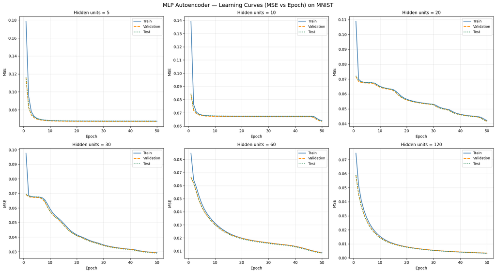

```python
epochs  = range(1, NUM_EPOCHS + 1)
n_plots = len(HIDDEN_UNITS_LIST)
n_cols  = 3
n_rows  = (n_plots + n_cols - 1) // n_cols

fig, axes = plt.subplots(n_rows, n_cols, figsize=(6 * n_cols, 5 * n_rows))
axes = np.array(axes).flatten()

for idx, h in enumerate(HIDDEN_UNITS_LIST):
    _, train_l, val_l, test_l = all_results[h]
    ax = axes[idx]

    ax.plot(epochs, train_l, color='steelblue',  linewidth=1.8, label='Train')
    ax.plot(epochs, val_l,   color='darkorange', linewidth=1.8,
            linestyle='--', label='Validation')
    ax.plot(epochs, test_l,  color='seagreen',   linewidth=1.8,
            linestyle=':',  label='Test')

    ax.set_title(f'Hidden units = {h}', fontsize=11)
    ax.set_xlabel('Epoch')
    ax.set_ylabel('MSE')
    ax.legend(fontsize=9)
    ax.grid(True, alpha=0.3)

for idx in range(n_plots, len(axes)):
    axes[idx].set_visible(False)

fig.suptitle('MLP Autoencoder — Learning Curves (MSE vs Epoch) on MNIST', fontsize=14)
plt.tight_layout()
plt.show()
```

## 9. Digit "3" Reconstruction MSE vs. Bottleneck Size (Q1 — Part 1)

This bar chart summarizes how well each model reconstructs the digit "3" specifically. The assignment asks us to evaluate MSE for digit 3 with different hidden unit counts.

We expect MSE to decrease as the number of hidden units increases — more capacity means the autoencoder can encode finer details of the digit's shape.

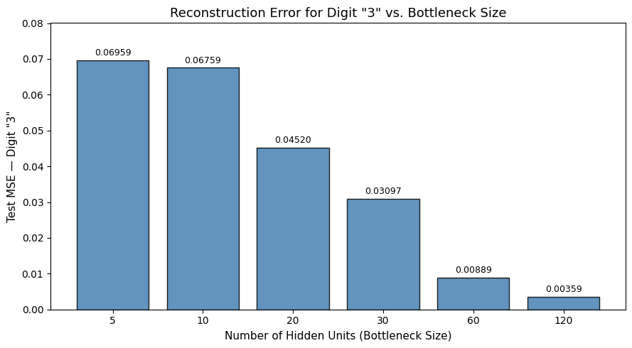

```
Digit '3' Reconstruction MSE by bottleneck size:
    5 hidden units → MSE = 0.069595
   10 hidden units → MSE = 0.067588
   20 hidden units → MSE = 0.045197
   30 hidden units → MSE = 0.030969
   60 hidden units → MSE = 0.008889
  120 hidden units → MSE = 0.003594
```

```python
hs   = list(digit3_mse.keys())
mses = list(digit3_mse.values())

fig, ax = plt.subplots(figsize=(9, 5))
bars = ax.bar([str(h) for h in hs], mses, color='steelblue', edgecolor='black', alpha=0.85)

for bar, mse_val in zip(bars, mses):
    ax.text(bar.get_x() + bar.get_width() / 2,
            bar.get_height() + max(mses) * 0.01,
            f'{mse_val:.5f}', ha='center', va='bottom', fontsize=9)

ax.set_xlabel('Number of Hidden Units (Bottleneck Size)', fontsize=11)
ax.set_ylabel('Test MSE — Digit "3"', fontsize=11)
ax.set_title('Reconstruction Error for Digit "3" vs. Bottleneck Size', fontsize=13)
ax.set_ylim(0, max(mses) * 1.15)
plt.tight_layout()
plt.show()

# Print numeric results
print("\nDigit '3' Reconstruction MSE by bottleneck size:")
for h, m in digit3_mse.items():
    print(f"  {h:3d} hidden units → MSE = {m:.6f}")
```

## 10. Reconstruction Gallery — Digit "3" (Q1 — Part 1)

Here we visually compare the original digit "3" against its reconstruction from each model. This gives an intuitive sense of how compression quality improves with bottleneck size.

With only 5 hidden units, the reconstruction is blurry and loses detail. With 120 hidden units, the reconstruction is nearly indistinguishable from the original.

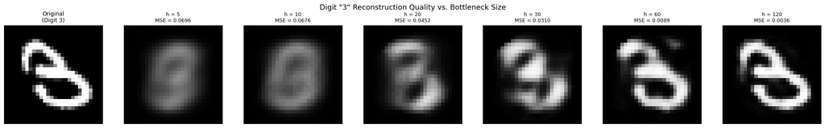

```python
# Find the first digit-3 in the test set
digit3_idx = np.where(test_labels == 3)[0][0]
sample_img = torch.from_numpy(test_images[digit3_idx]).unsqueeze(0).to(device)

n_models = len(HIDDEN_UNITS_LIST)
fig, axes = plt.subplots(1, n_models + 1, figsize=(3.0 * (n_models + 1), 3.2))

# Original image
axes[0].imshow(test_images[digit3_idx].reshape(28, 28), cmap='gray', vmin=0, vmax=1)
axes[0].set_title('Original\n(Digit 3)', fontsize=10)
axes[0].axis('off')

# Reconstructions from each model
for idx, h in enumerate(HIDDEN_UNITS_LIST):
    model = all_results[h][0]
    model.eval()
    with torch.no_grad():
        recon_np = model(sample_img).cpu().numpy().reshape(28, 28)

    axes[idx + 1].imshow(recon_np, cmap='gray', vmin=0, vmax=1)
    axes[idx + 1].set_title(f'h = {h}\nMSE = {digit3_mse[h]:.4f}', fontsize=9)
    axes[idx + 1].axis('off')

fig.suptitle('Digit "3" Reconstruction Quality vs. Bottleneck Size', fontsize=13)
plt.tight_layout()
plt.show()
```

## 11. Encoder Weight Visualization (Q1 — Part 2)

The encoder's weight matrix `W₁` has shape `(N, 784)`, where `N` is the number of hidden units. **Row `i`** of this matrix contains the 784 weights that connect every input pixel to hidden neuron `i`.

By reshaping row `i` from a 784-dimensional vector to a **28×28 image**, we can visualize what each hidden neuron has learned to detect:

- **Bright pixels** indicate strong positive weights — the neuron responds when those pixels are active
- **Dark pixels** indicate strong negative weights or near-zero weights

This visualization corresponds to the course notes on autoencoders (pp. 78–79).

### Encoder Weights — 10 Hidden Units

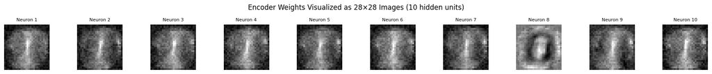

```python
h = 10
model = all_results[h][0]
W = model.get_encoder_weights()   # shape: (10, 784)

# Normalize each weight image individually to [0, 1] for display
W_min  = W.min(axis=1, keepdims=True)
W_max  = W.max(axis=1, keepdims=True)
W_norm = (W - W_min) / (W_max - W_min + 1e-8)

n_cols_w = min(h, 10)
n_rows_w = (h + n_cols_w - 1) // n_cols_w

fig, axes = plt.subplots(n_rows_w, n_cols_w, figsize=(n_cols_w * 1.8, n_rows_w * 1.8))
axes = np.array(axes).flatten()

for i in range(h):
    weight_img = W_norm[i].reshape(28, 28)
    axes[i].imshow(weight_img, cmap='gray', vmin=0, vmax=1)
    axes[i].set_title(f'Neuron {i + 1}', fontsize=8)
    axes[i].axis('off')

for i in range(h, len(axes)):
    axes[i].set_visible(False)

fig.suptitle(f'Encoder Weights Visualized as 28×28 Images ({h} hidden units)', fontsize=12)
plt.tight_layout()
plt.show()
```

### Encoder Weights — 20 Hidden Units

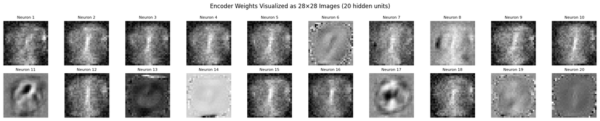

```python
h = 20
model = all_results[h][0]
W = model.get_encoder_weights()   # shape: (20, 784)

W_min  = W.min(axis=1, keepdims=True)
W_max  = W.max(axis=1, keepdims=True)
W_norm = (W - W_min) / (W_max - W_min + 1e-8)

n_cols_w = min(h, 10)
n_rows_w = (h + n_cols_w - 1) // n_cols_w

fig, axes = plt.subplots(n_rows_w, n_cols_w, figsize=(n_cols_w * 1.8, n_rows_w * 1.8))
axes = np.array(axes).flatten()

for i in range(h):
    weight_img = W_norm[i].reshape(28, 28)
    axes[i].imshow(weight_img, cmap='gray', vmin=0, vmax=1)
    axes[i].set_title(f'Neuron {i + 1}', fontsize=8)
    axes[i].axis('off')

for i in range(h, len(axes)):
    axes[i].set_visible(False)

fig.suptitle(f'Encoder Weights Visualized as 28×28 Images ({h} hidden units)', fontsize=12)
plt.tight_layout()
plt.show()
```